# Data Storytelling: Soccer Analytics

Victor H. Ayala Sánchez

La data utilizada en el presente conjunto de visualizaciones fue liberada en el año 2018 (el proveedor fue Wyscout) y el data set completo fue recopilado por Pappalardo et al.(2019) bajo CC BY 4.0 License para consulta pública, el mismo contiene información de eventos espacio temporales de las 5 principales ligas de fútbol de Europa de la temporada 2017-2018.

Citas:

- Pappalardo et al., (2019) A public data set of spatio-temporal match events in soccer competitions, Nature Scientific Data 6:236, https://www.nature.com/articles/s41597-019-0247-7
- Pappalardo et al. (2019) PlayeRank: Data-driven Performance Evaluation and Player Ranking in Soccer via a Machine Learning Approach. ACM Transactions on Intellingent Systems and Technologies (TIST) 10, 5, Article 59 (September 2019), 27 pages. DOI: https://doi.org/10.1145/3343172

Puedes conseguir el dataset completo y mayor informacióna acerca de la metodología y medición en el siguiente [link](https://figshare.com/collections/Soccer_match_event_dataset/4415000).

La PEC consiste en realizar un análisis visual de los datos del **Real Madrid**.

# Estadísticas Generales de los eventos

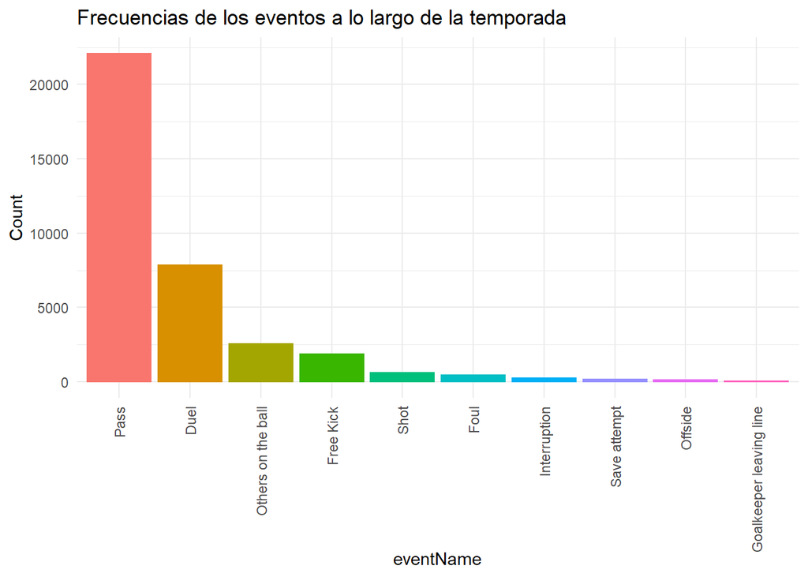

Líderes en el equipo en el número de pases en todas la temporada por jugador

| PlayerName | Count |
| --- | --- |
| Toni Kroos | 1958 |
| Sergio Ramos | 1777 |
| Marcelo | 1704 |
| Casemiro | 1648 |
| Dani Carvajal | 1609 |
| Isco | 1524 |
| Modric | 1511 |
| R. Varane | 1264 |
| Marco Asensio | 1160 |
| Nacho | 1082 |

# Análisis de los pases

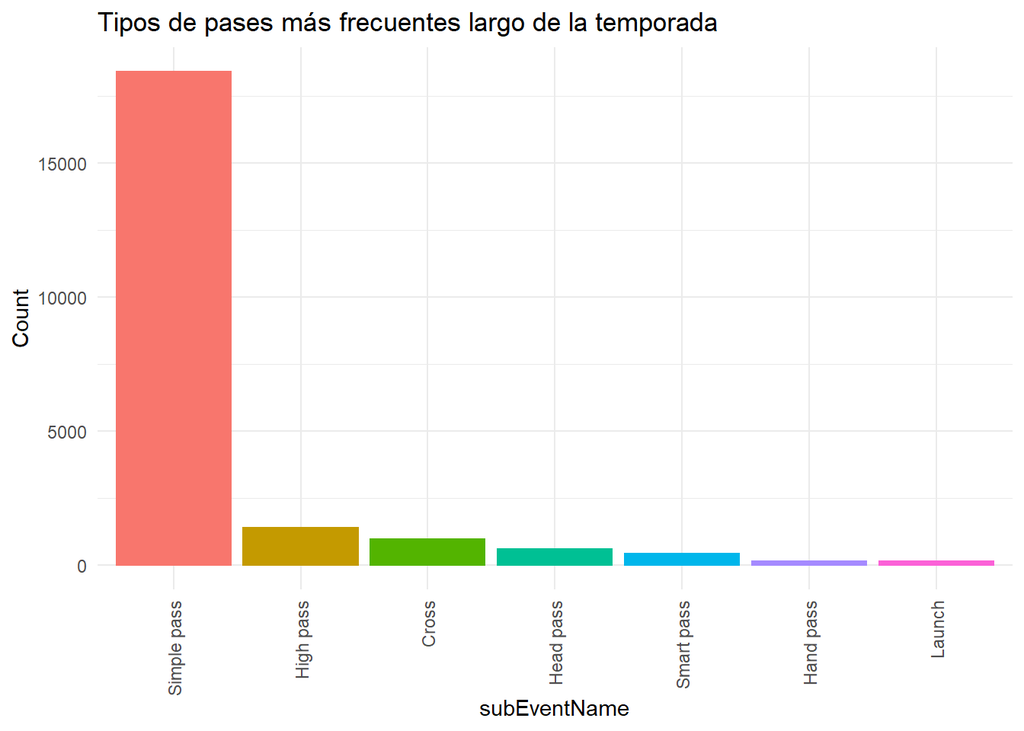

## Posición en el capo en el momento de los pases

### T. Kroos

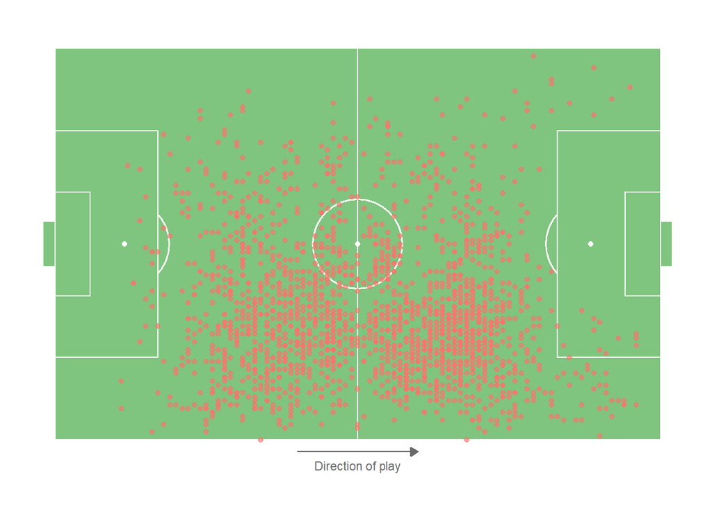

### L. Modric

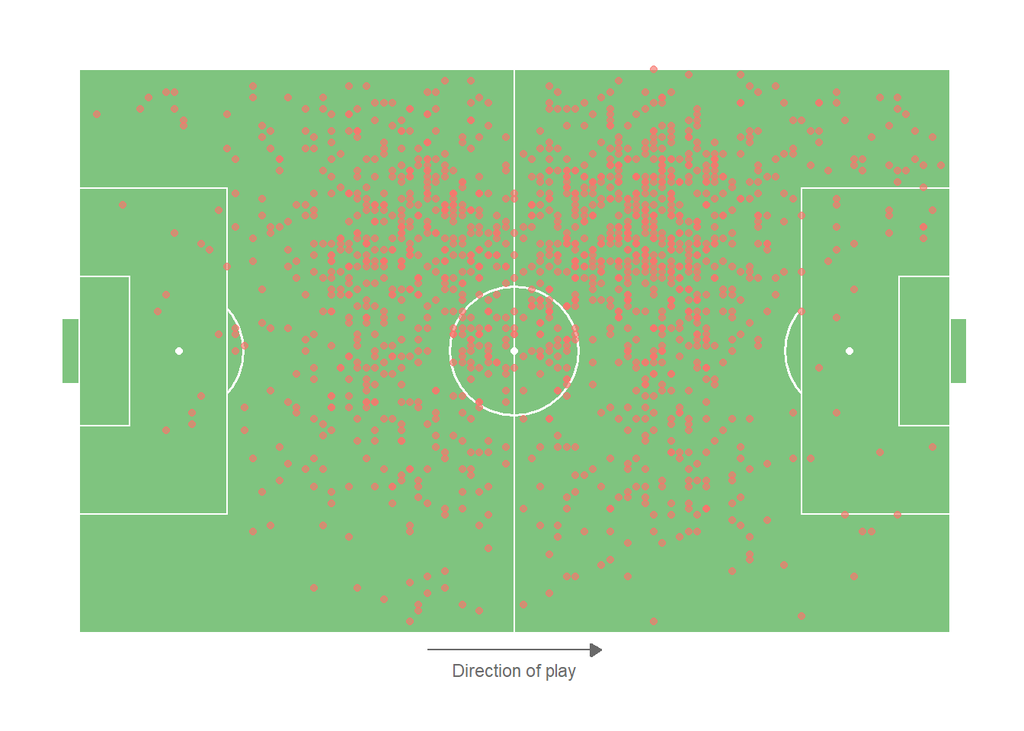

### Casemiro

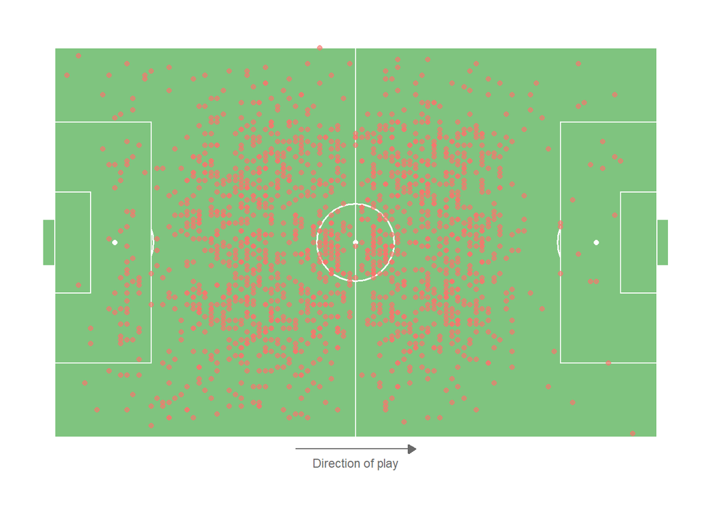

## Destino de los pases largos

### T. Kroos

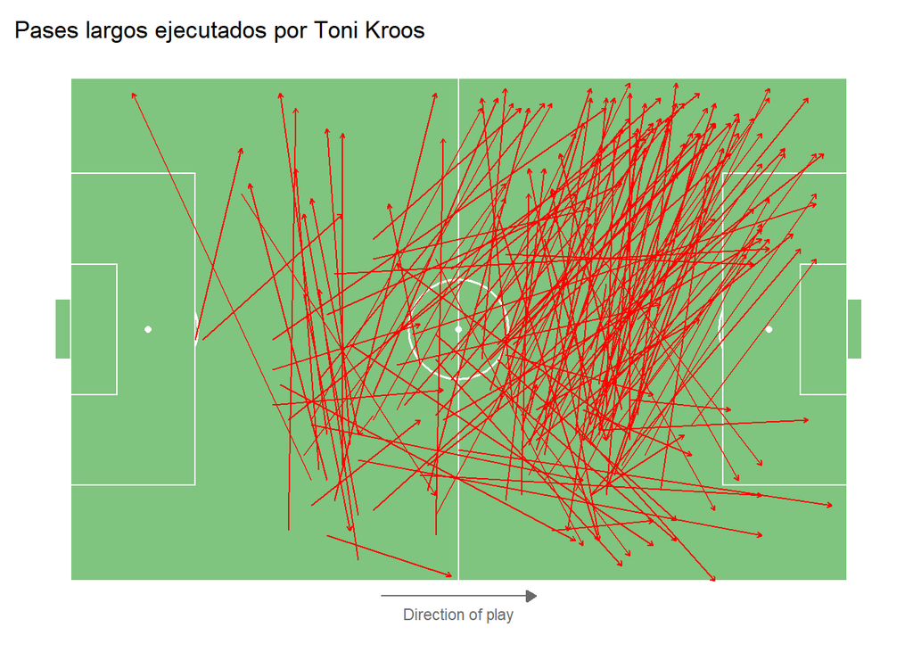

### L. Modric

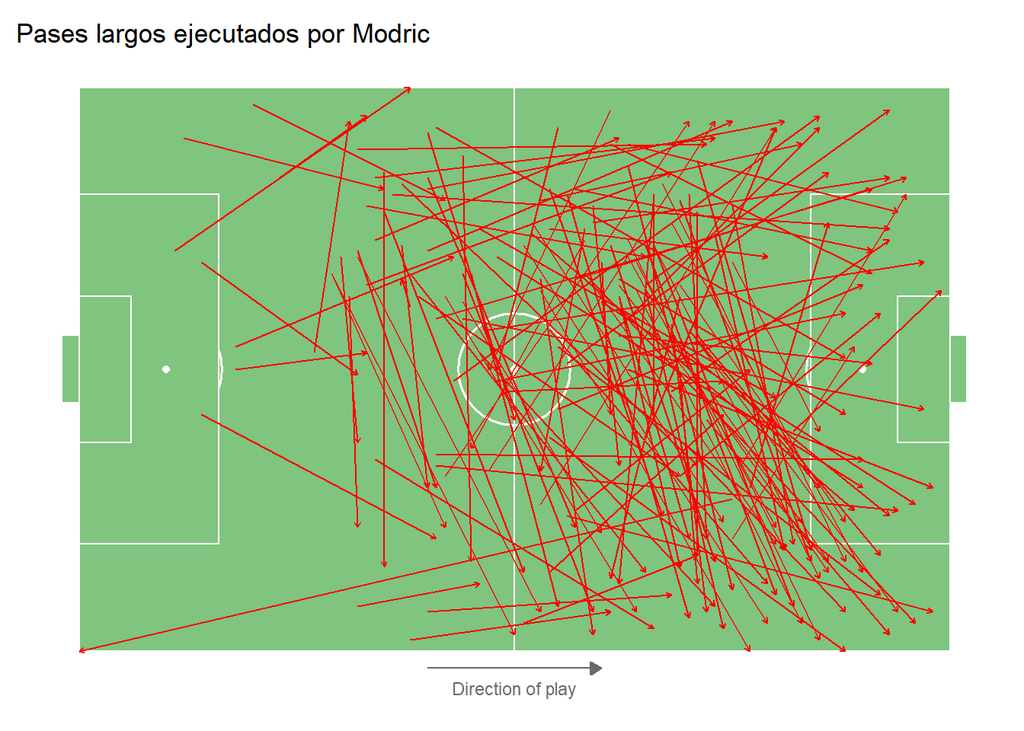

### Casemiro

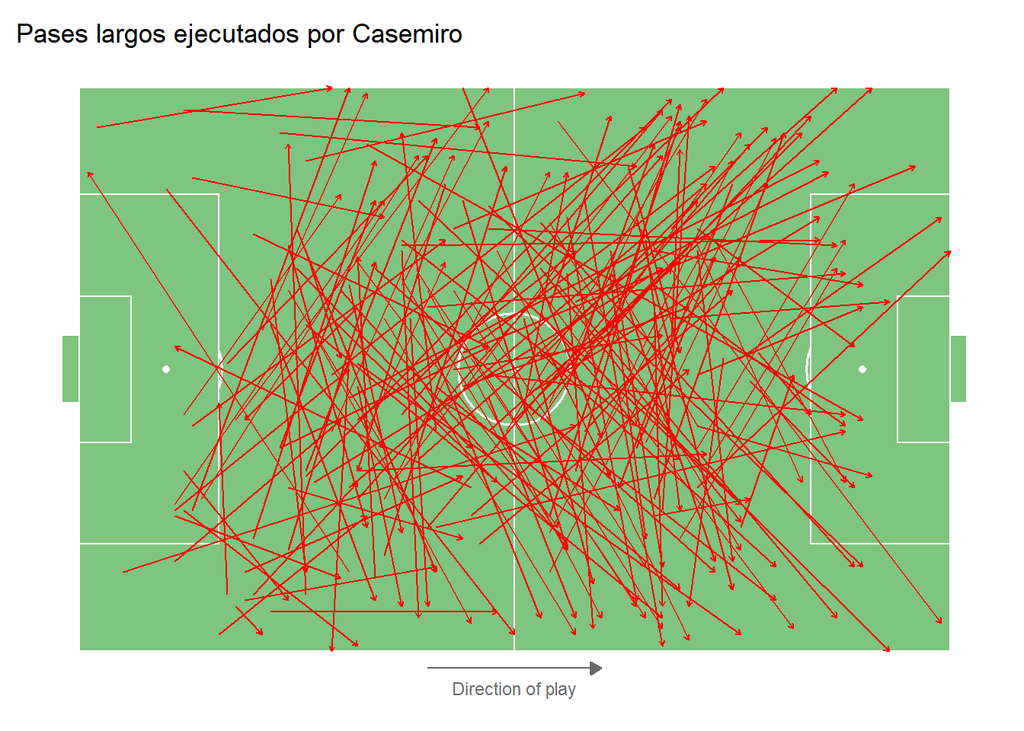

# Tiros al Arco

## Benzema

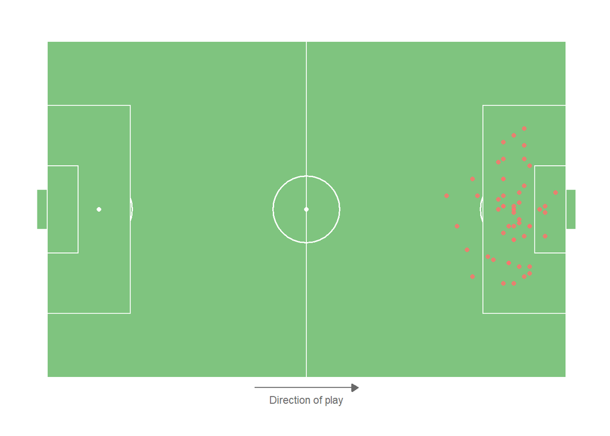

## Bale

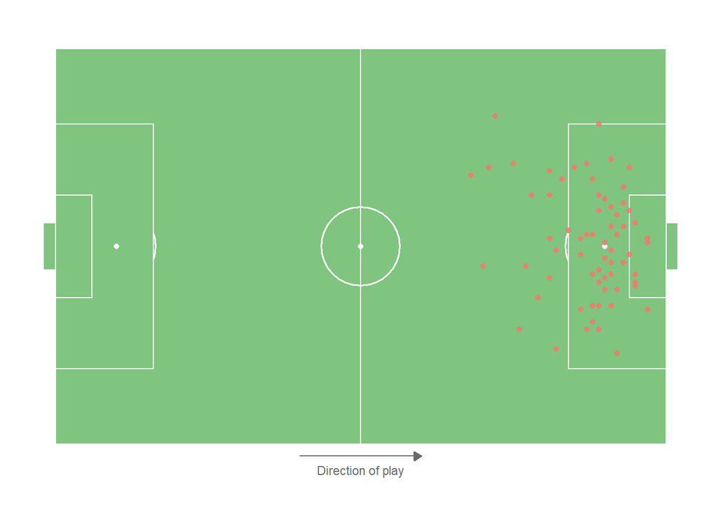

## M. Asensio

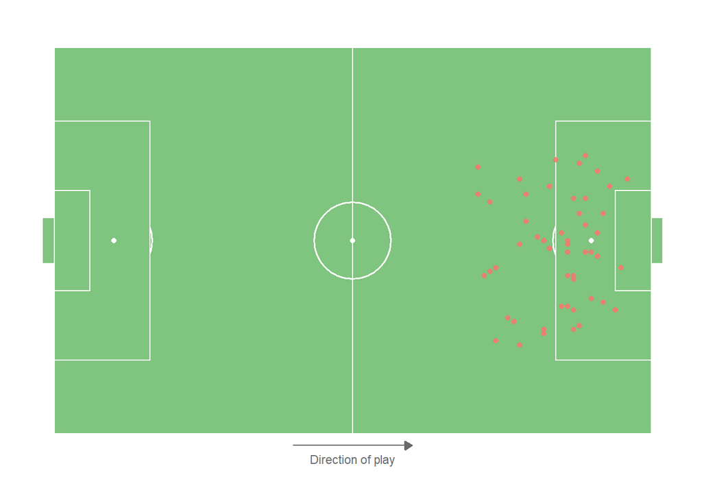